# FordGo Bike System

## Univariate Exploration

> In this section, distributions of individual variables will be investigated.

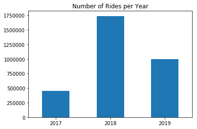

```python
#bar chart rides per year
df_clean['ride_year'].value_counts().sort_index().plot(kind ='bar', rot = 0)
plt.title('Number of Rides per Year');
```

> It's possible to see the increase of the rides through the years. Observe that we have data from 2019 just until May, and already more than half of the 2018's rides.

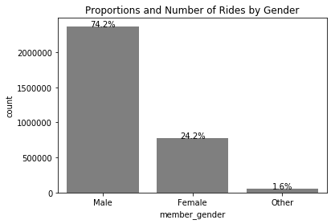

```python
# create the member_gender barplot
base_color = sb.color_palette()[7]
sb.countplot(data = df_clean, x = 'member_gender', color = base_color)

# add annotations
n_points = df_clean.shape[0]
cat_counts = df_clean['member_gender'].value_counts()
locs, labels = plt.xticks() # get the current tick locations and labels

# loop through each pair of locations and labels
for loc, label in zip(locs, labels):

    # get the text property for the label to get the correct count
    count = cat_counts[label.get_text()]
    pct_string = '{:0.1f}%'.format(100*count/n_points)

    # print the annotation just below the top of the bar
    plt.text(loc, count-8, pct_string, ha = 'center', color = 'black')
plt.title('Proportions and Number of Rides by Gender');
```

> There are three genders: male, female and other. The huge majority of the users of the system are male (74.2%). Comparing to the men, very few women are using bikes (24.2%).

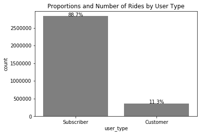

```python
# create the user_type barplot
base_color = sb.color_palette()[7]
cat_order = df_clean.user_type.value_counts().index
sb.countplot(data = df_clean, x = 'user_type', color = base_color, order = cat_order)

# add annotations
n_points = df_clean.shape[0]
cat_counts = df_clean['user_type'].value_counts()
locs, labels = plt.xticks() # get the current tick locations and labels

# loop through each pair of locations and labels
for loc, label in zip(locs, labels):

    # get the text property for the label to get the correct count
    count = cat_counts[label.get_text()]
    pct_string = '{:0.1f}%'.format(100*count/n_points)

    # print the annotation just below the top of the bar
    plt.text(loc, count-8, pct_string, ha = 'center', color = 'black')
plt.title('Proportions and Number of Rides by User Type');
```

> Related to the type of user, most users are subscriber, member of the service (88.7%). Just a few of them are casual customers (11.3%). It seems we can see a loyalty pattern in the use.

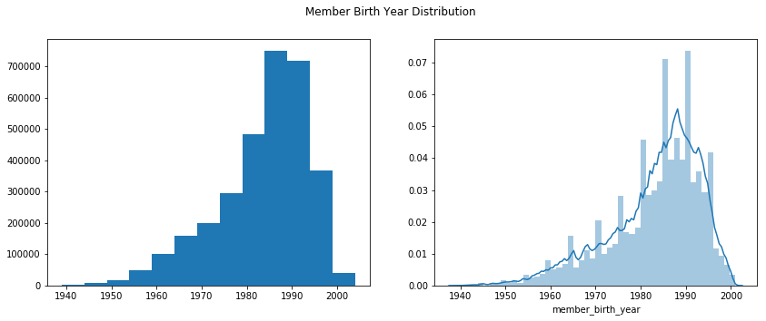

```python
# create the member_birth_year histogram
plt.figure(figsize = [14, 5])
plt.suptitle('Member Birth Year Distribution')

#histogram on left
plt.subplot(1, 2, 1)
bin_edges = np.arange(df_clean['member_birth_year'].min(), df_clean['member_birth_year'].max()+5, 5)
plt.hist(data= df_clean, x= 'member_birth_year', bins= bin_edges)

#histogram on right
plt.subplot(1, 2, 2)
sb.distplot(df_clean['member_birth_year']);
```

```python
#member_birth_year range
df_clean['member_birth_year'].max() - df_clean['member_birth_year'].min()
```

```
62
```

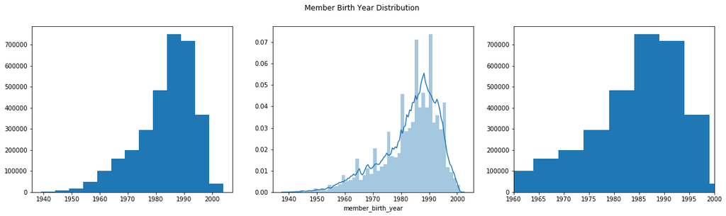

```python
#creating the member_birth_year histogram
plt.figure(figsize = [20, 5])
plt.suptitle('Member Birth Year Distribution')

#histogram on left
plt.subplot(1, 3, 1)
bin_edges = np.arange(df_clean['member_birth_year'].min(), df_clean['member_birth_year'].max()+5, 5)
plt.hist(data= df_clean, x= 'member_birth_year', bins= bin_edges)

#histogram on middle
plt.subplot(1, 3, 2)
sb.distplot(df_clean['member_birth_year'])

plt.subplot(1, 3, 3)
bin_edges = np.arange(df_clean['member_birth_year'].min(), df_clean['member_birth_year'].max()+5, 5)
plt.hist(data= df_clean, x= 'member_birth_year', bins= bin_edges)
plt.xlim(1960, 2000);
```

```python
#Creating a new column generation binning member_birth_year
#2000 to present: New Silent Generation or Generation Z
#1980 to 2000: Millennials or Generation Y
#1965 to 1979: Thirteeners or Generation X
#1946 to 1964: Baby Boomers
#1925 to 1945: Silent Generation

bin_edges = [1925, 1945, 1964, 1979, 2000, np.inf]
bin_names = ['Silent', 'Baby Boomers', 'Generation X', 'Millennials', 'New Silent']
df_clean['generations'] = pd.cut(df_clean['member_birth_year'], bin_edges, labels= bin_names).astype(str)
df_clean.generations.value_counts()
```

```
Millennials     2287359
Generation X     703496
Baby Boomers     197523
Silent             4672
New Silent          323
Name: generations, dtype: int64
```

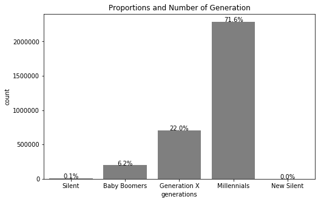

```python
# create the user_type barplot
base_color = sb.color_palette()[7]
plt.figure(figsize=(8, 5))
cat_order = ['Silent', 'Baby Boomers', 'Generation X', 'Millennials', 'New Silent']
sb.countplot(data = df_clean, x = 'generations', color = base_color, order= cat_order)

# add annotations
n_points = df_clean.shape[0]
cat_counts = df_clean['generations'].value_counts()
locs, labels = plt.xticks() # get the current tick locations and labels

# loop through each pair of locations and labels
for loc, label in zip(locs, labels):

    # get the text property for the label to get the correct count
    count = cat_counts[label.get_text()]
    pct_string = '{:0.1f}%'.format(100*count/n_points)

    # print the annotation just below the top of the bar
    plt.text(loc, count-8, pct_string, ha = 'center', color = 'black')
plt.title('Proportions and Number of Generation');
```

> The distribution of the number of rides throughout the years shows an increase. The distribution of the birth years appears to be unimodal and left skewed. The distribution starts to really increase in the year 1980 and highly decrease in 2000. Most of the users are between 1985-1995. Where we find the Millennials or Generation Y (1980 to 2000), according to Neil Howe and William Strauss. What indicates that it could be interesting to aggregate the data by generation to see how the distribution behaves. Also, old birth years caught our attention. Although it's possible, it's unusual to find someone who is 80 riding a bike.  
> Proving the prevalence of the Millennials generation, it was found 71.6% of them against less than 0.3% of Silent and New Silent generations.

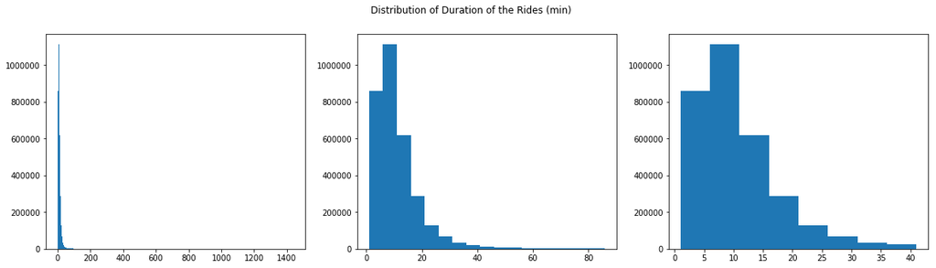

```python
#creating the duration_min histogram
plt.figure(figsize = [20, 5])

#left
plt.subplot(1, 3, 1)
bin_edges = np.arange(df_clean['duration_min'].min(), df_clean['duration_min'].max()+5, 5)
plt.hist(data= df_clean, x= 'duration_min', bins= bin_edges)

#middle
plt.subplot(1, 3, 2)
bin_edges = np.arange(df_clean['duration_min'].min(),90, 5)
plt.hist(data= df_clean, x= 'duration_min', bins= bin_edges)

#right
plt.subplot(1, 3, 3)
bin_edges = np.arange(df_clean['duration_min'].min(),45, 5)
plt.hist(data= df_clean, x= 'duration_min', bins= bin_edges)

plt.suptitle('Distribution of Duration of the Rides (min) ');
```

```python
df_clean['duration_min'].min()
```

```
1
```

> The distribution of the duration of the rides showed to be largely wide because of the outliers. So, it was better to see a dicing of the data. First, from the minimum to 90 min. As the majority of the rides are between the minimum and 40 minutes, the second dicing was between that interval. Those alternatives showed us a distribution unimodal and right-skewed, with the most rides concentrated between 1 and 20 minutes. That minimum duration should conduct us to reflect about canceled rides and investigate start and end stations.